# Practice Final Problems

Please contribute if you see any errors. Thanks.

### Problem 1.

#### Part (a)

This test does not require distributional assumptions. It uses ranks and is comparable to a paired t-test.

$\bigcirc$ Mann-Whitney Test

**ANSWER** Wilxocon Rank Sign Test

$\bigcirc$ Bootstrap

$\bigcirc$ Kruskal-Wallis Test

#### Part (b)

This method allows us to create confidence intervals based off of a simulated sampling distribution.

$\bigcirc$ t-Test

$\bigcirc$ Wilxocon Rank Sum Test

**ANSWER** Bootstrap

$\bigcirc$ Permutation Test

#### Part (c)

This method uses relabels to simulated the distribution under the null hypothesis.

**ANSWER** Permutation Test

$\bigcirc$ Kruskal-Wallis Test

$\bigcirc$ Wilxocon Rank Sign Test

$\bigcirc$ z-test

#### Part (d)

This nonparametric test is comparable to an ANOVA F-test.

$\bigcirc$ Permutation Test

**ANSWER** Kruskal-Wallis Test

$\bigcirc$ Wilxocon Rank Sign Test

$\bigcirc$ z-test

### Problem 2.

*The following problem cites [this study](https://www.sciencedirect.com/science/article/pii/S2215036618301354) (Mithoefer et al). You can learn more about the study’s data [here](https://clinicaltrials.gov/ct2/show/NCT01211405).*

The 2018 paper by Mithoefer et al studied the effect of MDMA (3,4-methylenedioxymethamphetamine) on military veterans, firefighters, and police officers with post-traumatic stress disorder. Each of the subjects (n=26) were given different doses of MDMA and a psychotherapy session, then had their Clinician-Administered PTSD scale score was measured.

| Low dose MDMA | Medium dose MDMA | High dose MDMA |
| --- | --- | --- |
| n=7 | n=7 | n=12 |
| 30 mg | 75 mg | 125 mg |

The study wants to test their hypotheses about whether these 3 groups had the same mean Clinician-Administered PTSD scale score.

Here is another table for more information.

|  | 30 mg | 75 mg | 125 mg |
| --- | --- | --- | --- |
| Mean PTSD duration | 68.9 | 58.3 | 110.9 |

#### Part (a)

The following is the start of a DAG for this study.

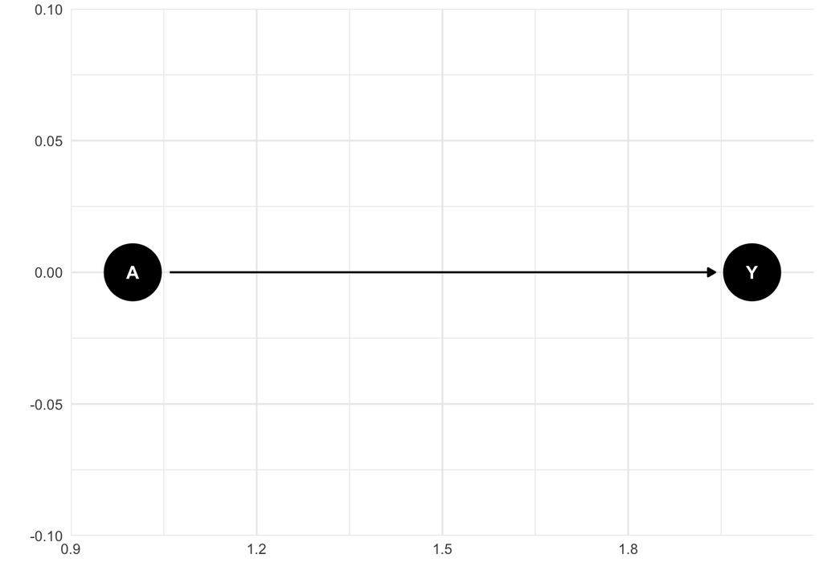

**1. What is $A$ in the study?**  
MDMA and psychotherapy.

**2. What is $Y$ in the study?**  
Clinician-Administrered PTSD scale score.

**3. What kind of study is this?**  
This is an experiment / randomized controlled trial. The study collected its data in a prospective manner. We want to know if MDMA and psychotherapy causes an improved PTSD scale score (causative).

**4. What test should this study use to test their hypotheses?**  
An ANOVA F test.

#### Part (b)

Can you tell if the assumptions for this test completely satisfied? Choose an answer, then elaborate in the space below the answer.

$\bigcirc$ Yes

**ANSWER** No

We cannot tell if the assumptions are completely satisfied. We have no information on the distributions of the PTSD scores’ normality or if their standard deviations are similar between all three groups.